# Predicting ADBE Stock Prices with Machine Learning

```python
!pip install pandas numpy matplotlib scikit-learn statsmodels tensorflow
!pip install alpha_vantage pandas
```

## Import libraries

```python
import pandas as pd
import numpy as np
import requests
import matplotlib.pyplot as plt
import matplotlib.dates as mdates
from alpha_vantage.timeseries import TimeSeries
from sklearn.model_selection import train_test_split
from sklearn.linear_model import LinearRegression
from sklearn.metrics import mean_squared_error, r2_score
from sklearn import metrics
from sklearn.metrics import confusion_matrix, accuracy_score
from sklearn.preprocessing import MinMaxScaler
from keras.models import Sequential
from keras.layers import LSTM, Dense, Input
from datetime import datetime, timedelta
import datetime
import math
```

```python
with open ("ALPHA_VANTAGE_API_KEY.txt") as file:
    ALPHA_VANTAGE_API_KEY = file.read()
```

```python
#print example API key
ALPHA_VANTAGE_API_KEY
```

```
'5WOP0YHEMHOLY6A4'
```

```python
#strip the text API key to get rid of spaces ans newline characters
ALPHA_VANTAGE_API_KEY = ALPHA_VANTAGE_API_KEY.strip()
```

```python
#open file
with open ("ALPHA_VANTAGE_API_KEY.txt") as file:
    API_key = file.read()
API_key = API_key.strip()
```

## Geting Intraday Data from Alpha Vantage

```python
url = 'https://www.alphavantage.co/query?function=TIME_SERIES_INTRADAY&symbol=ADBE&interval=5min&apikey=API_key'
r = requests.get(url)
data = r.json()

time_series_key = 'Time Series (5min)'
if time_series_key in data:
    time_series_data = data[time_series_key]
    df = pd.DataFrame.from_dict(time_series_data, orient='index')
    df.columns = ['Open', 'High', 'Low', 'Close', 'Volume']
    df.index = pd.to_datetime(df.index)
    df = df.astype(float)
    df = df.sort_index()
    print(df)
else:
    print(f"Key '{time_series_key}' not found in the data.")
```

```
                        Open     High      Low    Close   Volume
2024-06-24 11:40:00  530.010  530.010  528.560  528.560  18268.0
2024-06-24 11:45:00  528.651  528.651  527.670  528.515  38787.0
2024-06-24 11:50:00  528.490  528.850  528.360  528.834  13802.0
2024-06-24 11:55:00  528.745  529.290  528.260  529.170  17145.0
2024-06-24 12:00:00  529.080  529.380  528.885  529.020  33650.0
...                      ...      ...      ...      ...      ...
2024-06-24 19:35:00  524.200  528.590  524.200  525.040     49.0
2024-06-24 19:40:00  526.545  526.545  524.222  524.222    302.0
2024-06-24 19:45:00  524.460  525.250  524.210  524.300    279.0
2024-06-24 19:50:00  524.300  524.300  524.200  524.300     81.0
2024-06-24 19:55:00  524.300  527.870  524.300  524.300     63.0

[100 rows x 5 columns]
```

## Fetch Daily Data and Preprocess

### This function fetches daily stock data, processes it by filtering the date range, renaming columns, and dropping any missing values. The data is then printed for verification.

```python
# Fetch the data
def fetch_daily_data(symbol, API_key):
    ts = TimeSeries(key=API_key, output_format='pandas')
    data, meta_data = ts.get_daily(symbol=symbol, outputsize='full')
    data = data[(data.index >= '2020-01-01') & (data.index <= '2024-10-06')]
    data.columns = ['Open', 'High', 'Low', 'Close', 'Volume']
    # Check for missing values and handle them
    data = data.dropna()
    return data
```

```python
# Fetch data for Adobe Inc (ADBE)
symbol = 'ADBE'
API_key = API_key
df_adbe = fetch_daily_data(symbol, API_key)
print("Fetched Data:")
print(df_adbe.head())
print(df_adbe.tail())
```

```
Fetched Data:
               Open    High      Low   Close     Volume
date
2024-06-24  532.100  534.58  523.480  524.17  3067824.0
2024-06-21  530.310  535.00  524.715  533.44  6614086.0
2024-06-20  527.665  533.23  520.400  522.95  5752373.0
2024-06-18  514.710  530.37  513.130  522.25  4225943.0
2024-06-17  525.510  525.94  505.380  518.74  7163820.0
              Open    High      Low   Close     Volume
date
2020-01-08  333.81  339.23  333.400  337.87  2248531.0
2020-01-07  334.15  334.79  332.305  333.39  2507261.0
2020-01-06  328.29  333.91  328.190  333.71  1875122.0
2020-01-03  329.17  332.98  328.690  331.81  1579371.0
2020-01-02  330.00  334.48  329.170  334.43  1990496.0
```

```python
# Check the data for anomalies
print("Checking for missing values...")
print(df_adbe.isnull().sum())
```

```
Checking for missing values...
Open      0
High      0
Low       0
Close     0
Volume    0
dtype: int64
```

```python
print("\nData description:")
print(df_adbe.describe())
```

```
Data description:
              Open         High          Low        Close        Volume
count  1126.000000  1126.000000  1126.000000  1126.000000  1.126000e+03
mean    466.804594   472.779635   460.483021   466.832966  3.084784e+06
std      98.758466    98.952453    98.244661    98.621837  1.835587e+06
min     277.800000   279.590000   255.131400   275.200000  5.891820e+05
25%     378.732500   383.613750   374.660000   379.010000  2.084881e+06
50%     471.970000   477.250000   464.240000   471.500000  2.609842e+06
75%     527.433750   534.457500   519.270000   528.355000  3.508244e+06
max     696.275000   699.540000   678.910000   688.370000  2.784021e+07
```

```python
df_adbe.shape
```

```
(1126, 5)
```

### This block visualizes the closing prices of ADBE to give a visual understanding of the stock's performance over time.

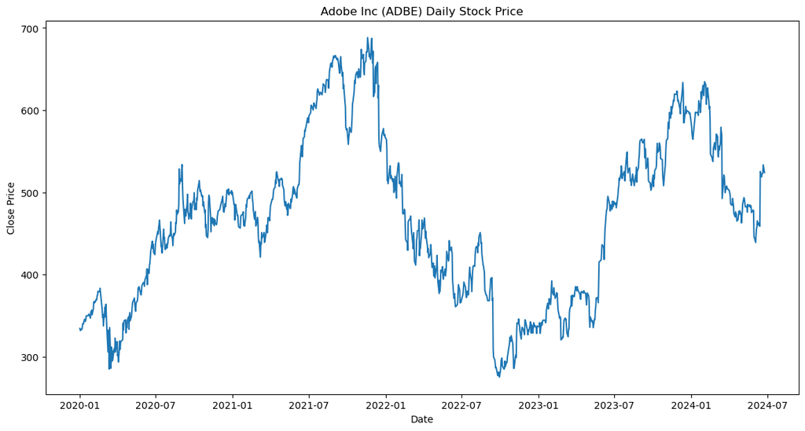

```python
# Visualize the data
plt.figure(figsize=(14, 7))
plt.plot(df_adbe['Close'])
plt.title('Adobe Inc (ADBE) Daily Stock Price')
plt.xlabel('Date')
plt.ylabel('Close Price')
plt.show()
```

## Data Preprocessing for LSTM

### The closing prices are scaled to a range of 0 to 1 using MinMaxScaler. This normalization is crucial for the performance of LSTM networks

```python
# Feature scaling for LSTM
scaler = MinMaxScaler(feature_range=(0, 1))
scaled_data = scaler.fit_transform(df_adbe[['Close']])
```

```python
#Display scaled data
print("Scaled Data:")
print(scaled_data[:5])
```

```
Scaled Data:
[[0.60258489]
 [0.62502118]
 [0.59963211]
 [0.59793789]
 [0.5894426 ]]
```

### This function creates the dataset for the LSTM model by generating sequences of 60 time steps for the features (X) and the corresponding target values (y). The data is reshaped to be suitable for LSTM input.

```python
# Create dataset for LSTM
def create_lstm_dataset(data, look_back=60):
    X, y = [], []
    for i in range(len(data) - look_back):
        X.append(data[i:(i + look_back), 0])
        y.append(data[i + look_back, 0])
    return np.array(X), np.array(y)

look_back = 60
X, y = create_lstm_dataset(scaled_data, look_back)
X = X.reshape((X.shape[0], X.shape[1], 1))
#Display LSTM dataset
print("LSTM Dataset - X")
print(X[:2])
print("LSTM Datase - y")
print(y[:2])
```

```
LSTM Dataset - X
[[[0.60258489]
  [0.62502118]
  [0.59963211]
  [0.59793789]
  [0.5894426 ]
  [0.60534405]
  [0.44422393]
  [0.44695888]
  [0.45378416]
  [0.4471283 ]
  [0.46041581]
  [0.44274754]
  [0.43710821]
  [0.4191253 ]
  [0.39649539]
  [0.41038798]
  [0.41307452]
  [0.489871  ]
  [0.49187986]
  [0.48461892]
  [0.50369097]
  [0.50519157]
  [0.50015732]
  [0.507031  ]
  [0.50398141]
  [0.50265024]
  [0.50862841]
  [0.48587748]
  [0.50320691]
  [0.50122226]
  [0.50209357]
  [0.51528427]
  [0.52537696]
  [0.52857177]
  [0.51063727]
  [0.48737808]
  [0.47000024]
  [0.454123  ]
  [0.47890699]
```

[output cut: 69 more lines]

```
  [0.47171866]
  [0.4813757 ]
  [0.50603868]
  [0.51315439]
  [0.52605465]
  [0.50603868]
  [0.50807174]
  [0.51288816]
  [0.53684924]
  [0.54217392]
  [0.54914442]
  [0.5552194 ]
  [0.55473534]]]
LSTM Datase - y
[0.55473534 0.56248033]
```

## Build the LSTM Model

### The data is split into training and test sets, with 80% of the data used for training and 20% for testing.

```python
# Split into train and test sets
train_size = int(len(X) * 0.8)
X_train, X_test = X[:train_size], X[train_size:]
y_train, y_test = y[:train_size], y[train_size:]
```

```python
# Build the LSTM model
model = Sequential([
    Input(shape=(look_back, 1)),
    LSTM(50, return_sequences=True),
    LSTM(50),
    Dense(1)
])
```

```python
# Compile the model
model.compile(optimizer='adam', loss='mean_squared_error')
```

```python
# Train the model
model.fit(X_train, y_train, epochs=20, batch_size=32, validation_split=0.2)
```

```
22/22 ━━━━━━━━━━━━━━━━━━━━ 5s 49ms/step - loss: 0.1015 - val_loss: 0.0026
22/22 ━━━━━━━━━━━━━━━━━━━━ 1s 27ms/step - loss: 0.0086 - val_loss: 0.0022
22/22 ━━━━━━━━━━━━━━━━━━━━ 1s 28ms/step - loss: 0.0045 - val_loss: 0.0034
22/22 ━━━━━━━━━━━━━━━━━━━━ 1s 25ms/step - loss: 0.0041 - val_loss: 0.0031
22/22 ━━━━━━━━━━━━━━━━━━━━ 1s 27ms/step - loss: 0.0039 - val_loss: 0.0025
22/22 ━━━━━━━━━━━━━━━━━━━━ 1s 30ms/step - loss: 0.0045 - val_loss: 0.0021
22/22 ━━━━━━━━━━━━━━━━━━━━ 1s 27ms/step - loss: 0.0041 - val_loss: 0.0029
22/22 ━━━━━━━━━━━━━━━━━━━━ 1s 27ms/step - loss: 0.0036 - val_loss: 0.0018
22/22 ━━━━━━━━━━━━━━━━━━━━ 1s 27ms/step - loss: 0.0033 - val_loss: 0.0017
22/22 ━━━━━━━━━━━━━━━━━━━━ 1s 27ms/step - loss: 0.0031 - val_loss: 0.0018
22/22 ━━━━━━━━━━━━━━━━━━━━ 1s 28ms/step - loss: 0.0029 - val_loss: 0.0016
22/22 ━━━━━━━━━━━━━━━━━━━━ 1s 25ms/step - loss: 0.0030 - val_loss: 0.0018
22/22 ━━━━━━━━━━━━━━━━━━━━ 1s 27ms/step - loss: 0.0030 - val_loss: 0.0014
22/22 ━━━━━━━━━━━━━━━━━━━━ 1s 26ms/step - loss: 0.0031 - val_loss: 0.0017
22/22 ━━━━━━━━━━━━━━━━━━━━ 1s 26ms/step - loss: 0.0031 - val_loss: 0.0015
22/22 ━━━━━━━━━━━━━━━━━━━━ 1s 27ms/step - loss: 0.0028 - val_loss: 0.0012
22/22 ━━━━━━━━━━━━━━━━━━━━ 1s 27ms/step - loss: 0.0028 - val_loss: 0.0011
22/22 ━━━━━━━━━━━━━━━━━━━━ 1s 27ms/step - loss: 0.0027 - val_loss: 0.0011
22/22 ━━━━━━━━━━━━━━━━━━━━ 1s 27ms/step - loss: 0.0025 - val_loss: 0.0010
22/22 ━━━━━━━━━━━━━━━━━━━━ 1s 26ms/step - loss: 0.0024 - val_loss: 0.0010
```

```
<keras.src.callbacks.history.History at 0x1bf88b43950>
```

## Make Predictions and Evaluate the Model

### Predictions are made on the test set, then inverse-transformed to the original scale. The root mean squared error (RMSE) is calculated to evaluate the model's performance

```python
# Make predictions
train_predict = model.predict(X_train)
test_predict = model.predict(X_test)
```

```
27/27 ━━━━━━━━━━━━━━━━━━━━ 1s 22ms/step
7/7 ━━━━━━━━━━━━━━━━━━━━ 0s 9ms/step
```

```python
train_predict = scaler.inverse_transform(train_predict)
test_predict = scaler.inverse_transform(test_predict)
y_train = scaler.inverse_transform(y_train.reshape(-1, 1))
y_test = scaler.inverse_transform(y_test.reshape(-1, 1))
```

```python
# Calculate RMSE and R²
train_rmse = np.sqrt(mean_squared_error(y_train, train_predict))
test_rmse = np.sqrt(mean_squared_error(y_test, test_predict))
train_r2 = r2_score(y_train, train_predict)
test_r2 = r2_score(y_test, test_predict)
```

```python
print(f"Train RMSE: {train_rmse}, Train R²: {train_r2}")
print(f"Test RMSE: {test_rmse}, Test R²: {test_r2}")
```

```
Train RMSE: 19.692540910306775, Train R²: 0.9632132318669803
Test RMSE: 15.785412558198097, Test R²: 0.940267165679221
```

## Visualize the Results

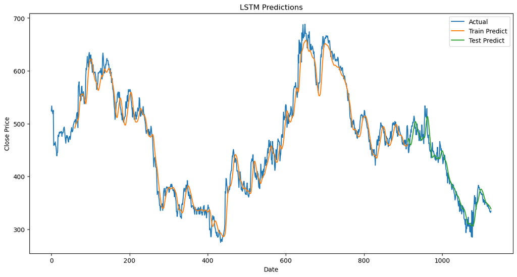

```python
# Plot the results
plt.figure(figsize=(14, 7))
plt.plot(scaler.inverse_transform(scaled_data), label='Actual')
plt.plot(np.arange(look_back, look_back + len(train_predict)), train_predict, label='Train Predict')
plt.plot(np.arange(look_back + len(train_predict), look_back + len(train_predict) + len(test_predict)), test_predict, label='Test Predict')
plt.title('LSTM Predictions')
plt.xlabel('Date')
plt.ylabel('Close Price')
plt.legend()
plt.show()
```

### Finally I used LSTM neural networks to predict stock prices for Adobe Inc. It involves data fetching, preprocessing, model building, training, and evaluation. Each step is crucial for developing an accurate and reliable predictive model.

## Linear Regression

```python
# remove spaces from column names and convert all to lowercase
df_adbe.columns = [c.lower() for c in df_adbe.columns]
```

```python
# Create target column by shifting 'Close' prices
df_adbe['target'] = df_adbe['close'].shift(-1)
```

```python
# Extracting features and target variable
X = df_adbe[['open', 'high', 'low', 'volume']]
y = df_adbe['close']
print(X)
```

```
               open    high      low     volume
date
2024-06-24  532.100  534.58  523.480  3067824.0
2024-06-21  530.310  535.00  524.715  6614086.0
2024-06-20  527.665  533.23  520.400  5752373.0
2024-06-18  514.710  530.37  513.130  4225943.0
2024-06-17  525.510  525.94  505.380  7163820.0
...             ...     ...      ...        ...
2020-01-08  333.810  339.23  333.400  2248531.0
2020-01-07  334.150  334.79  332.305  2507261.0
2020-01-06  328.290  333.91  328.190  1875122.0
2020-01-03  329.170  332.98  328.690  1579371.0
2020-01-02  330.000  334.48  329.170  1990496.0

[1126 rows x 4 columns]
```

```python
# print info for df_adbe
df_adbe.info()
```

```
<class 'pandas.core.frame.DataFrame'>
DatetimeIndex: 1126 entries, 2024-06-24 to 2020-01-02
Data columns (total 6 columns):
 #   Column  Non-Null Count  Dtype
---  ------  --------------  -----
 0   open    1126 non-null   float64
 1   high    1126 non-null   float64
 2   low     1126 non-null   float64
 3   close   1126 non-null   float64
 4   volume  1126 non-null   float64
 5   target  1125 non-null   float64
dtypes: float64(6)
memory usage: 61.6 KB
```

```python
# Splitting the data into training and testing sets
X_train, X_test, y_train, y_test = train_test_split(X, y, test_size=0.2, shuffle=True, random_state=42)
```

```python
# Confirm how the data was split
print(X_train.shape)
print(X_test.shape)
print(y_train.shape)
print(y_test.shape)
```

```
(900, 4)
(226, 4)
(900,)
(226,)
```

```python
# Instantiate the linear regression model
linear_model = LinearRegression()
# Train the model
linear_model.fit(X_train, y_train)
```

```
LinearRegression()
```

```python
#run the predictions on the training and testing data
y_pred_test = linear_model.predict(X_test)
```

```python
#compare the actual values (ie, target) with the values predicted by the model
pred_test_df = pd.DataFrame({'Actual': y_test, 'Predicted': y_pred_test}).sort_index()

pred_test_df
```

| date | Actual | Predicted |
| --- | --- | --- |
| 2020-01-10 | 339.81 | 341.054860 |
| 2020-01-15 | 342.94 | 344.012858 |
| 2020-01-30 | 356.74 | 355.633984 |
| 2020-02-11 | 369.28 | 368.884193 |
| 2020-02-18 | 378.85 | 380.748680 |
| ... | ... | ... |
| 2024-05-09 | 482.65 | 484.053191 |
| 2024-05-20 | 484.69 | 481.199631 |
| 2024-06-05 | 455.80 | 456.430465 |
| 2024-06-07 | 465.43 | 467.249502 |
| 2024-06-18 | 522.25 | 526.797167 |

226 rows × 2 columns

## Evaluate the model using the 𝑅^2 metric

```python
# Determine accuracy uisng 𝑅^2
# 𝑅^2 : R squared is another way to evaluate the performance of a regression model.
# 1, means that the model is perfect and 0 means the the model will perform poorly.
r2_reg_model_test = round(linear_model.score(X_test, y_test),2)

print("R^2 Test: {}".format(r2_reg_model_test))
```

```
R^2 Test: 1.0
```

```python
# Intercept and Coefficients
intercept = linear_model.intercept_
coefficients = linear_model.coef_

print("Coefficients:", coefficients)
print("Intercept:", intercept)
```

```
Coefficients: [-6.41123523e-01  8.75917404e-01  7.65277130e-01 -5.45955352e-08]
Intercept: -0.22639452250325576
```

## Scatter plot

### A scatter plot is created to visualize the actual versus predicted close prices and a red dashed line representing the perfect prediction line is added for reference.

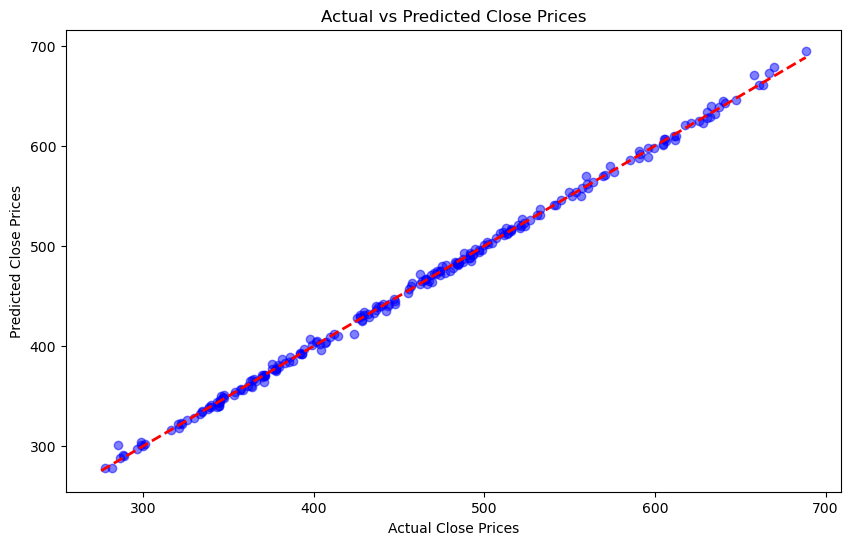

```python
# Plot the predictions against the actual values
plt.figure(figsize=(10, 6))
plt.scatter(y_test, y_pred_test, color='blue', alpha=0.5)
plt.plot([y.min(), y.max()], [y.min(), y.max()], color='red', linestyle='--', linewidth=2)
plt.xlabel('Actual Close Prices')
plt.ylabel('Predicted Close Prices')
plt.title('Actual vs Predicted Close Prices')
plt.show()
```

## Residual Plot

### This plot shows the residuals (differences between actual and predicted values), which can help in diagnosing the model's performance.

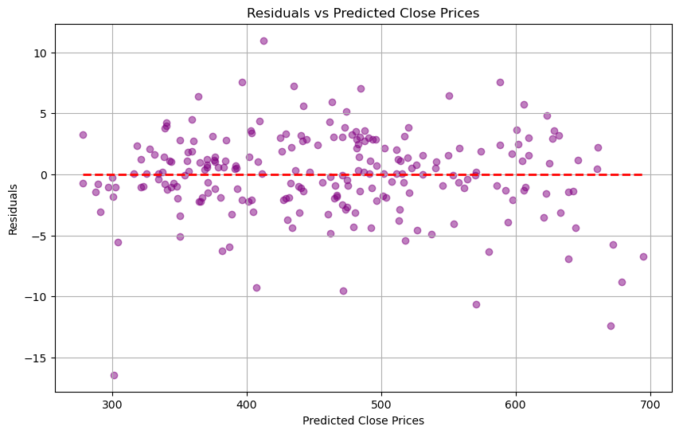

```python
# Calculating residuals
residuals = y_test - y_pred_test

# Plotting residuals
plt.figure(figsize=(10, 6))
plt.scatter(y_pred_test, residuals, color='purple', alpha=0.5)
plt.hlines(y=0, xmin=y_pred_test.min(), xmax=y_pred_test.max(), colors='red', linestyles='--', linewidth=2)
plt.xlabel('Predicted Close Prices')
plt.ylabel('Residuals')
plt.title('Residuals vs Predicted Close Prices')
plt.grid(True)
plt.show()
```

### The graph shows the actual vs. predicted stock prices, providing a visual representation of the model's performance.

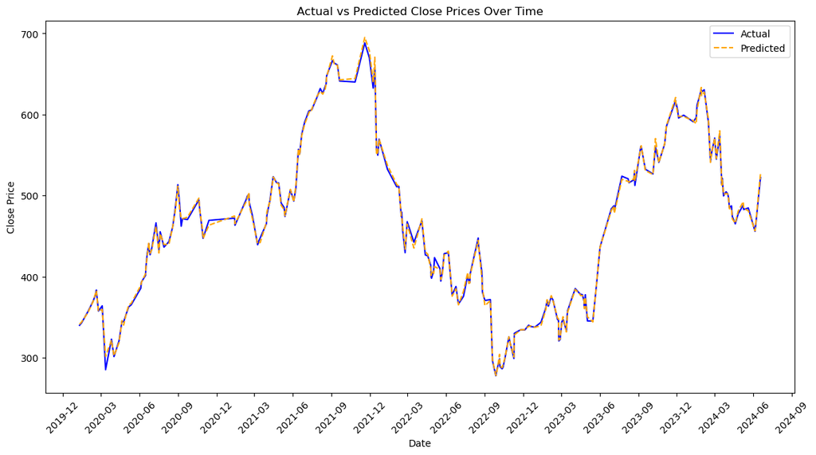

```python
# Plotting actual vs predicted values over time
plt.figure(figsize=(14, 7))

# Sorting the index for better visualization
pred_test_df = pred_test_df.sort_index()

plt.plot(pred_test_df.index, pred_test_df['Actual'], label='Actual', color='blue', linestyle='-', linewidth=1.5)
plt.plot(pred_test_df.index, pred_test_df['Predicted'], label='Predicted', color='orange', linestyle='--', linewidth=1.5)
plt.xlabel('Date')
plt.ylabel('Close Price')
plt.title('Actual vs Predicted Close Prices Over Time')
plt.legend()

# Formatting the x-axis to show dates nicely
plt.gca().xaxis.set_major_locator(mdates.MonthLocator(interval=3))
plt.gca().xaxis.set_major_formatter(mdates.DateFormatter('%Y-%m'))

plt.xticks(rotation=45)
plt.show()
```